# Practical Machine Learning

Doug Oliver

July 22, 2015

### Overview

It is now possible to collect a large amount of data about personal activity relatively inexpensively by using devices such as Jawbone Up, Nike FuelBand, and Fitbit. These type of devices are part of the quantified self-movement - a group of enthusiasts who take measurements about themselves regularly to improve their health, to find patterns in their behaviour, or because they are tech geeks. One thing that people regularly do is quantify how much of a particular activity they do, but they rarely quantify how well they do it. (2)

The paper(1) tells us that participants were asked to perform one set of 10 repetitions of the Unilateral Dumbbell Biceps Curl in five different fashions: exactly according to the specification. They were asked to perform barbell lifts correctly and incorrectly in 5 different ways. Class A corresponds to the specified execution of the exercise, while the other 4 classes correspond to common mistakes. More information is available from the website here: http://groupware.les.inf.puc-rio.br/har (see the section on the Weight Lifting Exercise Dataset). ‘Participants were supervised by an experienced weight lifter to make sure the execution complied to the manner they were supposed to simulate. The exercises were performed by six male participants aged between 20-28 years, with little weight lifting experience. We made sure that all participants could easily simulate the mistakes in a safe and controlled manner.’ (1)

The investigation is based on the Weight Lifting Exercise Dataset from http://groupware.les.inf.puc-rio.br/har. Due acknowledgement is given and the reference is shown in References(1).

### The Requirements

The goal is to use data from accelerometers on the belt, forearm, arm, and dumbbell of 6 participants to predict the manner in which they did the exercise. This is the “classe” variable in the training set. Any of the other variables may be used to predict with. A report should be created describing how the model was built, how cross validation was used, what the expected out of sample error is, and why the choices were made. The prediction model is to be used to predict the 20 different test cases.(2)

### Initialisation

The datasets can be downloaded from these links:

```r
#loading data and required packages
test <- read.csv("~/R/ml/pml-testing.csv", stringsAsFactors=FALSE)
training <- read.csv("~/R/ml/pml-training.csv",  na.strings=c("", "NA", "NULL"))
library(caret)
library(randomForest)
library(gbm)
library(e1071)
```

Parallel processing will be enabled with:

```r
library(doParallel)
registerDoParallel(cores=4)
```

### Data Preparations

We first look at the size and shape of the data.

```r
View(training)
summary(training)
head(training)
str(training)
```

```r
dim(training)
```

```
## [1] 19622   160
```

```r
dim(test)
```

```
## [1]  20 160
```

We can see that the number of columns is the same for both data sets. By comparing

```r
names(training)==names(test)
```

[output not shown]

We can observe that all column headings are the same except the last, where in the test set the classe has been replaced with problem_id.

We now consider the issue of missing variables.

```r
sum(is.na(training))/(19622*160)*100
```

```
## [1] 61.20681
```

```r
sum(is.na(test))/(20*160)*100
```

```
## [1] 62.5
```

There are a lot of N/A’s in both datasets, just over 60%. From a brief review of the training dataset, we can see that many of the columns have no values. It therefore seems unlikely that they can assist in the prediction, we will therefore remove them from the datasets which will make the training easier and will not affect the quality. To avoid potential problems we will specify that it is only columns where the N/A’s are greater than 75% are to be removed.

```r
training<-training[, colSums(is.na(training)) < nrow(training) * 0.75]
test<-test[, colSums(is.na(test)) < nrow(test) * 0.75]
```

This reduces the sizes of the datasets to:

```r
dim(training)
```

```
## [1] 19622    60
```

```r
dim(test)
```

```
## [1] 20 60
```

By re-running the names check, we see that all columns match except the last. This has in fact removed all of the N/A values from both datasets.

Looking at the variables, all but the first seven and the last are the measurements taken. We are predicting for the last variable, so the question is which (if any) of the first seven variables can be removed. The X column is simply a row number, this can be removed, user_name identifies the participants, as the actions were directed and marked accordingly, this will have no predictive value and can be removed, the three columns referring to timestamp relate to the calculation of when the activities were done, these can be removed. New window is a Boolean, yes/no, and can be removed. The paper(1) states that a moving window approach was used and implies that different results were observed for different window sizes. It is not clear what the numbers mean, however we will leave the column in place.

```r
training<- training[,-(1:6)]
test<- test[,-(1:6)]
```

There are also no near zero covariates.

```r
nearZeroVar(training)
```

```
## integer(0)
```

```r
nearZeroVar(test)
```

```
## integer(0)
```

### Cross Validation

Consideration was given as to whether to use a k-fold or hold-out method. In testing the k-fold produced slightly more optimistic results, we will therefore use the more pessimistic hold-out method.

The training set will be split into two portions in the ratio 75/25 so that we can train on the larger portion, test on the smaller and select the best performing model. The actual test set is reserved and the best model run against it.

```r
x<- createDataPartition(training$classe, p=0.75, list=F)
tr_train<-training[x,]
te_train<- training[-x,]
```

### Pre Processing

A test model is run to form a view if the predictor variables can be reduced.

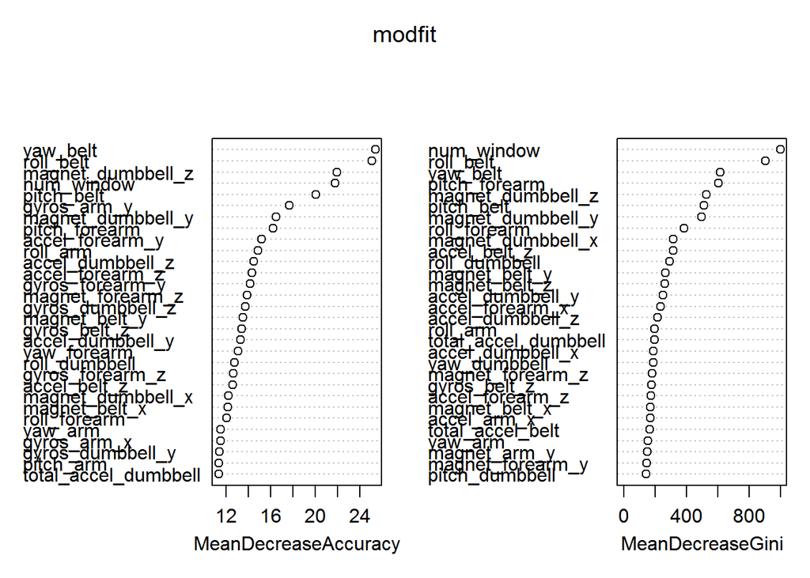

```r
set.seed(3234)
modfit<- randomForest(classe ~., data=tr_train, ntree=100, importance=TRUE)
varImpPlot(modfit)
```

This would seem to suggest that most of the variance is explained in about the first 10 variables, we will therefore include preProcess=‘pca’, where appropriate. This is confirmed by a review with a Generalized Boosted Regression Model (gbm).

```r
set.seed(3234)
modfit1<- gbm(classe ~., n.tree=5000, data=tr_train)
```

```
## Distribution not specified, assuming multinomial ...
```

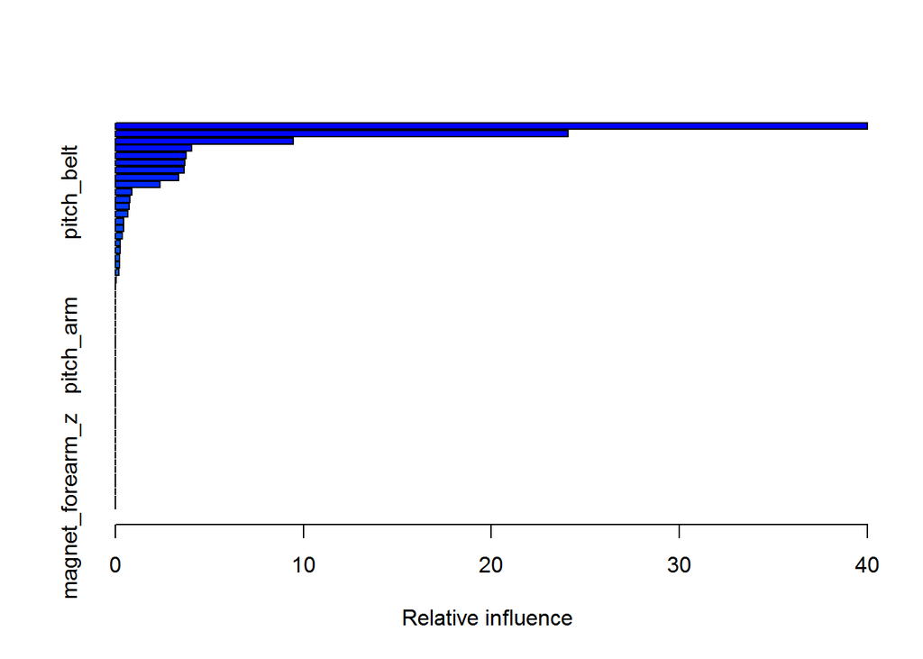

```
##                                       var     rel.inf
## roll_belt                       roll_belt 40.00531792
## pitch_forearm               pitch_forearm 24.09361423
## magnet_dumbbell_y       magnet_dumbbell_y  9.46173531
## roll_dumbbell               roll_dumbbell  4.04482798
## accel_forearm_x           accel_forearm_x  3.77811171
## roll_forearm                 roll_forearm  3.69881297
## yaw_belt                         yaw_belt  3.64649317
## num_window                     num_window  3.35871126
## gyros_dumbbell_y         gyros_dumbbell_y  2.38751041
## pitch_belt                     pitch_belt  0.89152939
## accel_dumbbell_x         accel_dumbbell_x  0.76965898
## magnet_dumbbell_z       magnet_dumbbell_z  0.74764029
## magnet_belt_z               magnet_belt_z  0.65129991
## magnet_dumbbell_x       magnet_dumbbell_x  0.42913092
## gyros_belt_z                 gyros_belt_z  0.42489065
## accel_dumbbell_y         accel_dumbbell_y  0.36267247
## magnet_arm_x                 magnet_arm_x  0.27453301
## pitch_dumbbell             pitch_dumbbell  0.26576071
## magnet_arm_z                 magnet_arm_z  0.22423078
## yaw_arm                           yaw_arm  0.22103199
## roll_arm                         roll_arm  0.19644018
## magnet_belt_y               magnet_belt_y  0.05133980
## gyros_arm_y                   gyros_arm_y  0.01470597
## total_accel_belt         total_accel_belt  0.00000000
## gyros_belt_x                 gyros_belt_x  0.00000000
## gyros_belt_y                 gyros_belt_y  0.00000000
## accel_belt_x                 accel_belt_x  0.00000000
## accel_belt_y                 accel_belt_y  0.00000000
## accel_belt_z                 accel_belt_z  0.00000000
## magnet_belt_x               magnet_belt_x  0.00000000
## pitch_arm                       pitch_arm  0.00000000
## total_accel_arm           total_accel_arm  0.00000000
## gyros_arm_x                   gyros_arm_x  0.00000000
## gyros_arm_z                   gyros_arm_z  0.00000000
## accel_arm_x                   accel_arm_x  0.00000000
## accel_arm_y                   accel_arm_y  0.00000000
## accel_arm_z                   accel_arm_z  0.00000000
## magnet_arm_y                 magnet_arm_y  0.00000000
## yaw_dumbbell                 yaw_dumbbell  0.00000000
## total_accel_dumbbell total_accel_dumbbell  0.00000000
## gyros_dumbbell_x         gyros_dumbbell_x  0.00000000
## gyros_dumbbell_z         gyros_dumbbell_z  0.00000000
## accel_dumbbell_z         accel_dumbbell_z  0.00000000
## yaw_forearm                   yaw_forearm  0.00000000
## total_accel_forearm   total_accel_forearm  0.00000000
## gyros_forearm_x           gyros_forearm_x  0.00000000
## gyros_forearm_y           gyros_forearm_y  0.00000000
## gyros_forearm_z           gyros_forearm_z  0.00000000
## accel_forearm_y           accel_forearm_y  0.00000000
## accel_forearm_z           accel_forearm_z  0.00000000
## magnet_forearm_x         magnet_forearm_x  0.00000000
## magnet_forearm_y         magnet_forearm_y  0.00000000
## magnet_forearm_z         magnet_forearm_z  0.00000000
```

```r
summary(modfit1)
```

### Model Selection

5 different models will be considered(3):

1. Random Forests
2. Recursive Partitioning and Regression Trees (rpart)
3. A Linear Discriminant Analysis (lda)
4. A Support Vector Machine (svm)
5. A Neural Network (nnet)

#### 1. Random Forest

In the caret package the method=‘rf’ runs very slowly on my pc random forest will therefore be run directly.

```r
set.seed(3234)
modfit<- randomForest(classe ~., data=tr_train, ntree=100, preProcess='pca', importance=TRUE)
modfit
```

```
##
## Call:
##  randomForest(formula = classe ~ ., data = tr_train, ntree = 100,      preProcess = "pca", importance = TRUE)
##                Type of random forest: classification
##                      Number of trees: 100
## No. of variables tried at each split: 7
##
##         OOB estimate of  error rate: 0.29%
## Confusion matrix:
##      A    B    C    D    E  class.error
## A 4184    1    0    0    0 0.0002389486
## B    8 2838    2    0    0 0.0035112360
## C    0    9 2556    2    0 0.0042851578
## D    0    0   13 2398    1 0.0058043118
## E    0    1    0    5 2700 0.0022172949
```

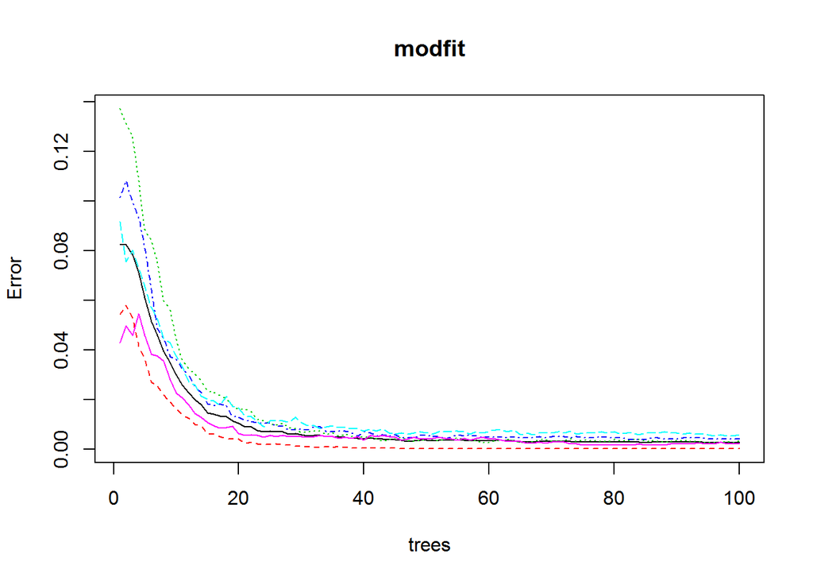

```r
plot(modfit)
```

The plot suggests that the fit is stable by about 40 trees, however as the model runs fairly quickly we will leave ntree at 100. The oob error estimate rate are identical. A high accuracy rate of about 99.7%.

Estimating the oob error from the te_train data.

```r
ans<-predict(modfit, te_train[,1:53], type='class')
cm<-confusionMatrix(te_train$classe, ans)
(1-sum(ans==te_train$classe)/length(te_train$classe))*100
```

```
## [1] 0.1835237
```

The error rate is a little better than the tr_train estimate.

#### 2. Recursive Partitioning and Regression Trees

```r
set.seed(3234)
modfit2<- train(classe ~., method='rpart',preProcess='pca', data=tr_train)
modfit2$results
```

```
##           cp  Accuracy      Kappa  AccuracySD    KappaSD
## 1 0.03973227 0.3511981 0.12535896 0.023203005 0.04837448
## 2 0.06028672 0.3372532 0.09555525 0.017788139 0.03427759
## 3 0.11554163 0.2833378 0.00000000 0.004509384 0.00000000
```

Estimating the oob error from the te_train data.

```r
ans2<-predict(modfit2, te_train[,1:53])
cm2<-confusionMatrix(ans2, te_train$classe)
(1-sum(ans2==te_train$classe)/length(te_train$classe))*100
```

```
## [1] 62.13295
```

This suggests an error rate of 62.13%. It seems also to have missed any predictions for C and D. This model can be discarded.

#### 3. A Linear Discriminant Analysis Model

```r
set.seed(3234)
modfit3<- train(classe ~., method='lda', data=tr_train, preProcess='pca')
modfit3$results
```

```
##   parameter  Accuracy     Kappa  AccuracySD    KappaSD
## 1      none 0.5385806 0.4161106 0.007485538 0.00928104
```

This suggests an error rate of 46.14% (Accuracy 53.86%), slightly better than a coin flip.

Estimating the oob error from the te_train data.

```r
ans3<-predict(modfit3, te_train[,-54])
cm3<-confusionMatrix(ans3, te_train$classe)
(1-sum(ans3==te_train$classe)/length(te_train$classe))*100
```

```
## [1] 46.04405
```

This suggests an error rate of 46.04%, about the same as the training set error estimate. This model can be discarded.

#### 4. A Support Vector Machine

```r
set.seed(3234)
modfit4<- svm(classe ~., data=tr_train, trControl=tc, preProcess='pca')
modfit4
```

```
##
## Call:
## svm(formula = classe ~ ., data = tr_train, trControl = tc, preProcess = "pca")
##
##
## Parameters:
##    SVM-Type:  C-classification
##  SVM-Kernel:  radial
##        cost:  1
##       gamma:  0.01886792
##
## Number of Support Vectors:  6534
```

Estimating the oob error from the te_train data.

```r
ans4<-predict(modfit4, te_train[,-54])
cm4<-confusionMatrix(ans4, te_train$classe)
(1-sum(ans4==te_train$classe)/length(te_train$classe))*100
```

```
## [1] 4.098695
```

This shows an error rate of 4.10% so is well worth considering.

#### 5. A Neural Network

```r
set.seed(3234)
modfit5<- train(classe ~., method='nnet', data=tr_train, preProcess='pca', verbose=FALSE)
```

```r
modfit5$results
```

```
##   size decay  Accuracy     Kappa AccuracySD    KappaSD
## 1    1 0e+00 0.3629311 0.1889044 0.01368185 0.01330569
## 2    1 1e-04 0.3614539 0.1832181 0.01338320 0.01755828
## 3    1 1e-01 0.3661215 0.1922518 0.01130047 0.01480921
## 4    3 0e+00 0.5080553 0.3817728 0.03764633 0.04724702
## 5    3 1e-04 0.5146949 0.3883503 0.02097338 0.02735657
## 6    3 1e-01 0.5239560 0.4001442 0.02299115 0.03142846
## 7    5 0e+00 0.5930955 0.4853031 0.02003338 0.02554421
## 8    5 1e-04 0.5976804 0.4908669 0.02076925 0.02702433
## 9    5 1e-01 0.6045780 0.5005195 0.02233403 0.02764860
```

This suggests an error rate of 39.54% (Accuracy 60.46%).

Estimating the oob error from the te_train data.

```r
ans5<-predict(modfit5, te_train[,-54])
cm5<-confusionMatrix(ans5, te_train$classe)
(1-sum(ans5==te_train$classe)/length(te_train$classe))*100
```

```
## [1] 36.70473
```

The te_train sample gives a slightly better estimate of 36.70%. This model can be discarded.

#### Conclusions

It is worth reviewing Random Forests and SVM to see how they perform in predicting against the test set.

```r
ans6<- predict(modfit, test)
ans7<- predict(modfit4, test)
ans6
```

```
##  1  2  3  4  5  6  7  8  9 10 11 12 13 14 15 16 17 18 19 20
##  B  A  B  A  A  E  D  B  A  A  B  C  B  A  E  E  A  B  B  B
## Levels: A B C D E
```

```r
ans7
```

```
##  1  2  3  4  5  6  7  8  9 10 11 12 13 14 15 16 17 18 19 20
##  B  A  B  A  A  E  D  B  A  A  B  C  B  A  E  E  A  B  B  B
## Levels: A B C D E
```

I will submit the answers produced by Random Forests because of its greater accuracy, stability and speed, however SVM performed creditably producing identical results on most runs, but on others row 3 was shown as A rather than B.

#### References

1. Velloso, E.; Bulling, A.; Gellersen, H.; Ugulino, W.; Fuks, H. Qualitative Activity Recognition of Weight Lifting Exercises. Proceedings of 4th International Conference in Cooperation with SIGCHI (Augmented Human ’13) . Stuttgart, Germany: ACM SIGCHI, 2013.
2. Practical Machine Learning - Write up requirements. https://class.coursera.org/predmachlearn-030/human_grading/view/courses/975199/assessments/4/submissions
3. https://cran.r-project.org/web/views/MachineLearning.html